# Bioinformatics 2021 HW_1

## 1.6 Problem 6:

**Plot the relationship between effective length, normalized read counts, TPM, and FPKM for this sample from the RSEM and Salmon output. Comment on the relative utility of each metric when analyzing gene expression data.**

> **绘制该样本中有效长度、归一化读取计数、TPM 和 FPKM 之间的关系图，使用 RSEM 和 Salmon 的输出结果。评论每个指标在分析基因表达数据时的相对实用性。**

```r
# 加载必要的库
library(ggplot2)
library(dplyr)
library(readr)

# 读取 RSEM 的基因定量结果
rsem_genes <- read_tsv("/home/huzongyao1/Homework_2020/HW1/output/rsem_Y/result.genes.results")
# 读取 RSEM 的转录本定量结果
rsem_isoforms <- read_tsv("/home/huzongyao1/Homework_2020/HW1/output/rsem_Y/result.isoforms.results")
# 读取 Salmon 的定量结果
salmon <- read_tsv("/home/huzongyao1/Homework_2020/HW1/output/salmon_Y/quant.sf")
# 提取所需的列
rsem_genes_filtered <- rsem_genes %>%
    select(gene_id,
        effective_length = `effective_length`,
        TPM = `TPM`, FPKM = `FPKM`, expected_count = `expected_count`
    )

rsem_isoforms_filtered <- rsem_isoforms %>%
    select(transcript_id,
        effective_length = `effective_length`,
        TPM = `TPM`, FPKM = `FPKM`, expected_count = `expected_count`
    )

salmon_filtered <- salmon %>%
    select(Name,
        effective_length = `EffectiveLength`,
        TPM = `TPM`, num_reads = `NumReads`
    )

# 画图函数定义
plot_relationships <- function(df, title_prefix) {
    # 有效长度 vs TPM
    p1 <- ggplot(df, aes(x = effective_length, y = TPM)) +
        geom_point(alpha = 0.5) +
        labs(title = paste(title_prefix, "Effective Length vs TPM"), x = "Effective Length", y = "TPM") +
        theme_minimal()

    # 有效长度 vs 转录本表达量预测
    p2 <- ggplot(df, aes(x = effective_length, y = expected_count)) +
        geom_point(alpha = 0.5) +
        labs(title = paste(title_prefix, "Effective Length vs Expected Count"), x = "Effective Length", y = "Expected Count") +
        theme_minimal()

    # TPM vs FPKM
    p3 <- ggplot(df, aes(x = TPM, y = FPKM)) +
        geom_point(alpha = 0.5) +
        labs(title = paste(title_prefix, "TPM vs FPKM"), x = "TPM", y = "FPKM") +
        theme_minimal() +
        geom_smooth(alpha = 0.5, method = "lm", se = FALSE)

    # TPM vs 转录本表达量预测
    p4 <- ggplot(df, aes(x = TPM, y = expected_count)) +
        geom_point(alpha = 0.5) +
        labs(title = paste(title_prefix, "TPM vs Expected Count"), x = "TPM", y = "Expected Count") +
        theme_minimal()

    # 将四张图组合显示
    gridExtra::grid.arrange(p1, p2, p3, p4, ncol = 2)
}

plot_relationships_salmon <- function(df, title_prefix) {
    # 有效长度 vs TPM
    p1 <- ggplot(df, aes(x = effective_length, y = TPM)) +
        geom_point(alpha = 0.5) +
        labs(title = paste(title_prefix, "Effective Length vs TPM"), x = "Effective Length", y = "TPM") +
        theme_minimal()

    # 有效长度 vs 转录本表达量
    p2 <- ggplot(df, aes(x = effective_length, y = num_reads)) +
        geom_point(alpha = 0.5) +
        labs(title = paste(title_prefix, "Effective Length vs Num Reads"), x = "Effective Length", y = "Num Reads") +
        theme_minimal()

    # TPM vs 转录本表达量
    p3 <- ggplot(df, aes(x = TPM, y = num_reads)) +
        geom_point(alpha = 0.5) +
        labs(title = paste(title_prefix, "TPM vs FPKM"), x = "TPM", y = "Num Reads") +
        theme_minimal()

    # 将3张图组合显示
    gridExtra::grid.arrange(p1, p2, p3, ncol = 2)
}


# 绘制 RSEM 基因的关系图
# png("RSEM_Genes.png", width = 800, height = 600) # 设置文件名和图形尺寸
# pdf("RSEM_Genes.pdf", width = 8, height = 6) # 设置文件名和图形尺寸
# plot_relationships(rsem_genes_filtered, "RSEM Genes")

# 绘制 RSEM 转录本的关系图
# png("RSEM_Isoforms.png", width = 800, height = 600) # 设置文件名和图形尺寸
# pdf("RSEM_Isoforms.pdf", width = 8, height = 6) # 设置文件名和图形尺寸
# plot_relationships(rsem_isoforms_filtered, "RSEM Isoforms")

# # 绘制 Salmon 的关系图
# png("Salmon.png", width = 800, height = 600) # 设置文件名和图形尺寸
# # pdf("Salmon.pdf", width = 8, height = 6) # 设置文件名和图形尺寸
# plot_relationships_salmon(salmon_filtered, "Salmon")

# dev.off()
```

> 得到3张图:

> 图1: RSEM 基因比对结果

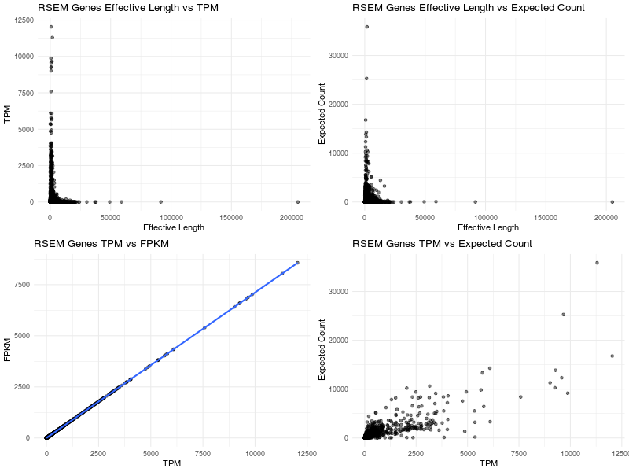

> 图2: RSEM 转录本比对结果

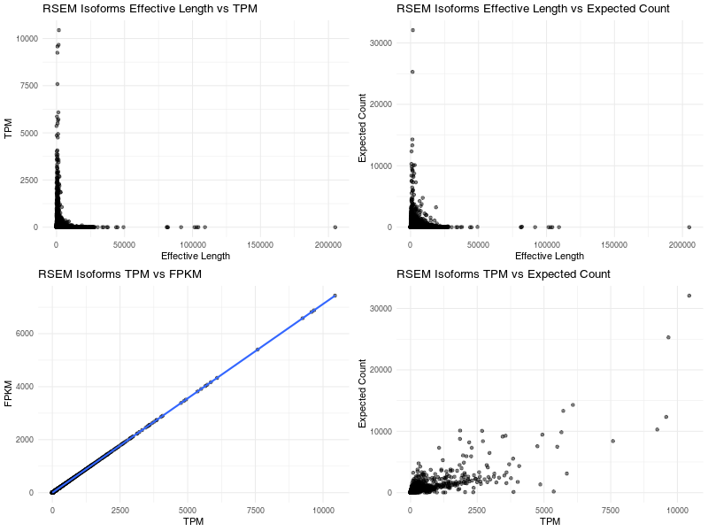

> 图3: Salmon 比对结果

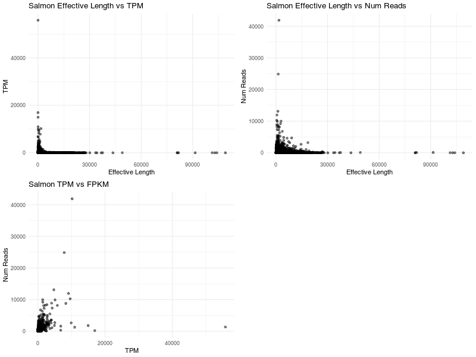

> 从图中可以看出，TPM 和 FPKM 之间有很强的相关性，呈非常明显的线性关系。其余关系（TPM与预计表达量、TMP与有效长度、有效长度与预计表达量）的关系并不明显。下面我将对所有数据取对数后再次绘制图形：

```r
# 加载必要的库
library(ggplot2)
library(dplyr)
library(readr)

# 读取 RSEM 的基因定量结果
rsem_genes <- read_tsv("/home/huzongyao1/Homework_2020/HW1/output/rsem_Y/result.genes.results")
# 读取 RSEM 的转录本定量结果
rsem_isoforms <- read_tsv("/home/huzongyao1/Homework_2020/HW1/output/rsem_Y/result.isoforms.results")
# 读取 Salmon 的定量结果
salmon <- read_tsv("/home/huzongyao1/Homework_2020/HW1/output/salmon_Y/quant.sf")
# 提取所需的列
rsem_genes_filtered <- rsem_genes %>%
    select(gene_id,
        effective_length = `effective_length`,
        TPM = `TPM`, FPKM = `FPKM`, expected_count = `expected_count`
    )

rsem_isoforms_filtered <- rsem_isoforms %>%
    select(transcript_id,
        effective_length = `effective_length`,
        TPM = `TPM`, FPKM = `FPKM`, expected_count = `expected_count`
    )

salmon_filtered <- salmon %>%
    select(Name,
        effective_length = `EffectiveLength`,
        TPM = `TPM`, num_reads = `NumReads`
    )

# 画图函数定义
plot_relationships <- function(df, title_prefix) {
    # 有效长度 vs TPM
    p1 <- ggplot(df, aes(x = log(effective_length), y = log(TPM))) +
        geom_point(alpha = 0.1) +
        labs(title = paste(title_prefix, "Effective Length vs TPM"), x = "log(Effective Length)", y = "log(TPM)") +
        theme_minimal()

    # 有效长度 vs 转录本表达量预测
    p2 <- ggplot(df, aes(x = log(effective_length), y = log(expected_count))) +
        geom_point(alpha = 0.1) +
        labs(title = paste(title_prefix, "Effective Length vs Expected Count"), x = "log(Effective Length)", y = "log(Expected Count)") +
        theme_minimal()

    # TPM vs FPKM
    p3 <- ggplot(df, aes(x = log(TPM), y = log(FPKM))) +
        geom_point(alpha = 0.1) +
        labs(title = paste(title_prefix, "TPM vs FPKM"), x = "log(TPM)", y = "log(FPKM)") +
        theme_minimal() +
        geom_smooth(alpha = 0.1, method = "lm", se = FALSE)

    # TPM vs 转录本表达量预测
    p4 <- ggplot(df, aes(x = log(TPM), y = log(expected_count))) +
        geom_point(alpha = 0.1) +
        labs(title = paste(title_prefix, "TPM vs Expected Count"), x = "log(TPM)", y = "log(Expected Count)") +
        theme_minimal()

    # 将四张图组合显示
    gridExtra::grid.arrange(p1, p2, p3, p4, ncol = 2)
}

plot_relationships_salmon <- function(df, title_prefix) {
    # 有效长度 vs TPM
    p1 <- ggplot(df, aes(x = log(effective_length), y = log(TPM))) +
        geom_point(alpha = 0.1) +
        labs(title = paste(title_prefix, "Effective Length vs TPM"), x = "log(Effective Length)", y = "log(TPM)") +
        theme_minimal()

    # 有效长度 vs 转录本表达量
    p2 <- ggplot(df, aes(x = log(effective_length), y = log(num_reads))) +
        geom_point(alpha = 0.1) +
        labs(title = paste(title_prefix, "Effective Length vs Num Reads"), x = "log(Effective Length)", y = "log(Num Reads)") +
        theme_minimal()

    # TPM vs 转录本表达量
    p3 <- ggplot(df, aes(x = log(TPM), y = log(num_reads))) +
        geom_point(alpha = 0.1) +
        labs(title = paste(title_prefix, "TPM vs FPKM"), x = "log(TPM)", y = "log(Num Reads)") +
        theme_minimal()

    # 将3张图组合显示
    gridExtra::grid.arrange(p1, p2, p3, ncol = 2)
}


# 绘制 RSEM 基因的关系图
# png("RSEM_Genes_log.png", width = 800, height = 600) # 设置文件名和图形尺寸
# pdf("RSEM_Genes_log.pdf", width = 8, height = 6) # 设置文件名和图形尺寸
# plot_relationships(rsem_genes_filtered, "RSEM Genes")

# 绘制 RSEM 转录本的关系图
# png("RSEM_Isoforms_log.png", width = 800, height = 600) # 设置文件名和图形尺寸
# pdf("RSEM_Isoforms_log.pdf", width = 8, height = 6) # 设置文件名和图形尺寸
# plot_relationships(rsem_isoforms_filtered, "RSEM Isoforms")

# # 绘制 Salmon 的关系图
# png("Salmon_log.png", width = 800, height = 600) # 设置文件名和图形尺寸
# # pdf("Salmon_log.pdf", width = 8, height = 6) # 设置文件名和图形尺寸
# plot_relationships_salmon(salmon_filtered, "Salmon")

# dev.off()
```

> 得到3张图:

> 图1: RSEM 基因比对结果

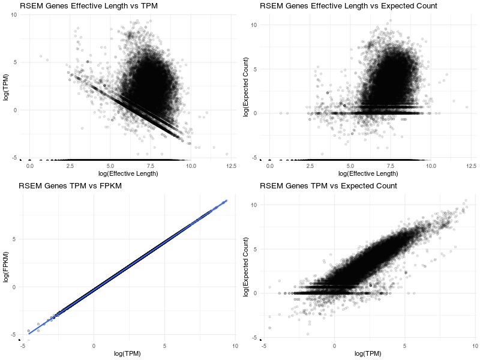

> 图2: RSEM 转录本比对结果

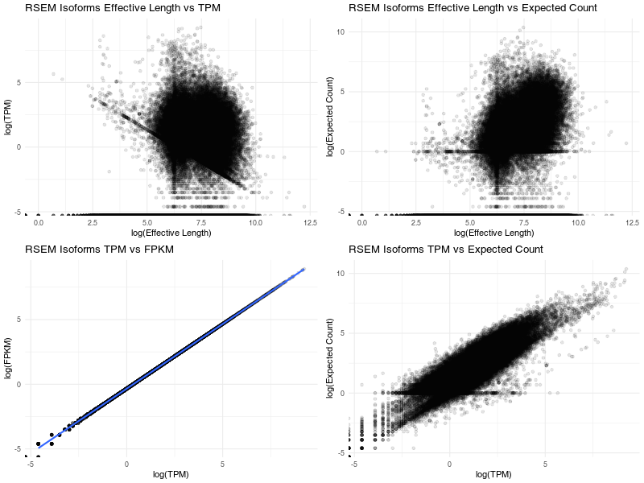

> 图3: Salmon 比对结果

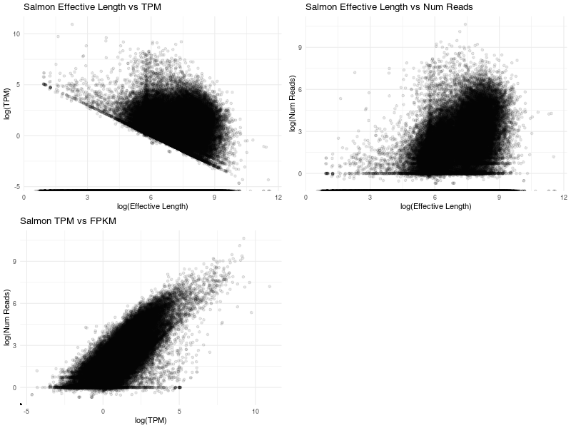

> 取对数后，图形更加清晰。TPM 和 FPKM 之间仍然呈线性关系。此外，TPM和预计表达量之间也发现了一定的正向相关性。但是其他指标之间的关系仍然不明显。

> **综上所述，TPM和FPKM在分析分析基因表达数据更加实用。也是最常用的。**

> 下面是 Github 上开源的[stat115 2020作业](https://github.com/stat115/Homework_2020)，与2021版完全不相同。但是由于之前不知道要做哪个版本的，所以也顺便做了一下练手。